# Flight Delay Analysis

Eduardo Gomez

02-14-2020

## Load packages and data

```r
# Load packages
library(tidyverse)
# Load data
d <- read_csv("flight_delay_clean.csv")
# Inspect data:
# Glimpse
glimpse(d)
```

```
## Observations: 360
## Variables: 13
## $ airline                 <chr> "RegionEx", "RegionEx", "RegionEx", "Reg…
## $ departure_date          <date> 2008-09-01, 2008-09-01, 2008-09-01, 200…
## $ origin                  <chr> "DFW", "DFW", "DFW", "DFW", "DFW", "DFW"…
## $ destination             <chr> "MSY", "MSY", "MSY", "MSY", "MSY", "MSY"…
## $ route_code              <chr> "DFW/MSY", "DFW/MSY", "DFW/MSY", "DFW/MS…
## $ scheduled_departure     <time> 09:10:00, 13:10:00, 18:10:00, 09:10:00,…
## $ scheduled_arrival       <time> 10:40:00, 14:40:00, 19:40:00, 10:40:00,…
## $ actual_arrival          <time> 11:00:00, 15:00:00, 19:58:00, 10:50:00,…
## $ scheduled_flight_length <dbl> 90, 90, 90, 90, 90, 90, 90, 90, 90, 90, …
## $ actual_flight_length    <dbl> 110, 110, 108, 100, 101, 100, 99, 99, 99…
## $ delay                   <dbl> 20, 20, 18, 10, 11, 10, 9, 9, 9, 10, 10,…
## $ delay_indicator         <dbl> 1, 1, 1, 0, 0, 0, 0, 0, 0, 0, 0, 0, 0, 0…
## $ day_of_week             <dbl> 2, 2, 2, 3, 3, 3, 4, 4, 4, 5, 5, 5, 6, 6…
```

```r
# Summary
summary(d)
```

```
##    airline          departure_date          origin
##  Length:360         Min.   :2008-09-01   Length:360
##  Class :character   1st Qu.:2008-09-08   Class :character
##  Mode  :character   Median :2008-09-15   Mode  :character
##                     Mean   :2008-09-15
##                     3rd Qu.:2008-09-23
##                     Max.   :2008-09-30
##  destination         route_code        scheduled_departure
##  Length:360         Length:360         Length:360
##  Class :character   Class :character   Class1:hms
##  Mode  :character   Mode  :character   Class2:difftime
##                                        Mode  :numeric
##
##
##  scheduled_arrival actual_arrival    scheduled_flight_length
##  Length:360        Length:360        Min.   : 70.00
##  Class1:hms        Class1:hms        1st Qu.: 75.00
##  Class2:difftime   Class2:difftime   Median : 90.00
##  Mode  :numeric    Mode  :numeric    Mean   : 85.83
##                                      3rd Qu.: 90.00
##                                      Max.   :100.00
##  actual_flight_length     delay        delay_indicator   day_of_week
##  Min.   : 59.00       Min.   :-13.00   Min.   :0.0000   Min.   :1.0
##  1st Qu.: 86.00       1st Qu.:  5.00   1st Qu.:0.0000   1st Qu.:2.0
##  Median : 97.00       Median : 11.00   Median :0.0000   Median :4.0
##  Mean   : 99.91       Mean   : 14.07   Mean   :0.2611   Mean   :3.9
##  3rd Qu.:108.25       3rd Qu.: 15.00   3rd Qu.:1.0000   3rd Qu.:6.0
##  Max.   :243.00       Max.   :153.00   Max.   :1.0000   Max.   :7.0
```

## Questions

Lightly comment your code and use pipes for readability.

Comment briefly on each of the questions, as directed. Only the the final question requires a lengthier response.

### Q1

Compute the mean, median, 90th percentile, and standard deviation of arrival delay minutes for RegionEx flights. Do the same for MDA flights. Which measure of central tendency would be most appropriate for comparing airline performance?

```r
d %>% #Use the entire dataset
  group_by(airline) %>% # then Group by Airline
  summarize( # Sumarize by showing:mean, median, perc_90 in terms of Delays
    mean = mean(delay),
    median = median(delay),
    perc_90 = quantile(delay, probs = c(.9)),
    standard_deviation = sd(d$delay, na.rm = TRUE)
  )
```

```
## # A tibble: 2 x 5
##   airline   mean median perc_90 standard_deviation
##   <chr>    <dbl>  <dbl>   <dbl>              <dbl>
## 1 MDA       10.9     13    16.1               23.0
## 2 RegionEx  15.7      9    21                 23.0
```

```r
# Show the default quartiles information (0%, 25%, 50%, 75%, 100%)
  quantile(d$delay)
```

```
##   0%  25%  50%  75% 100%
##  -13    5   11   15  153
```

### Q2

Inspect the distribution of RegionEx’s arrival delays by constructing a histogram of the number of arrival delay minutes of RegionEx’s flights. Do the same for MDA’s flights. How do these two distributions compare? Hint: use facet_wrap().

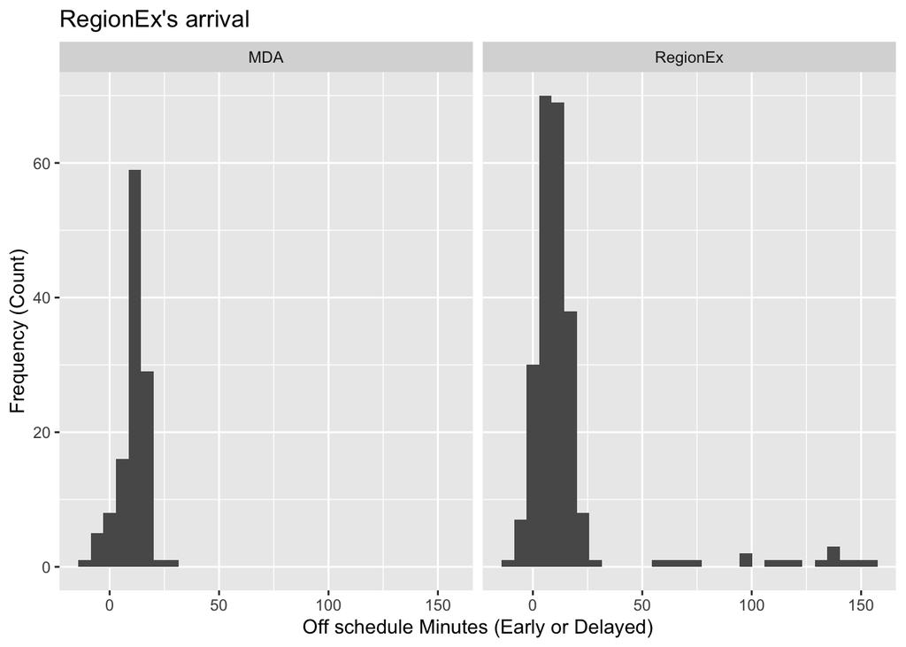

```r
ggplot(d, aes(x=delay)) +
  geom_histogram()+
  ggtitle("RegionEx's arrival") +
  xlab("Off schedule Minutes (Early or Delayed)") +
  ylab("Frequency (Count)") +
  facet_wrap(~d$airline)
```

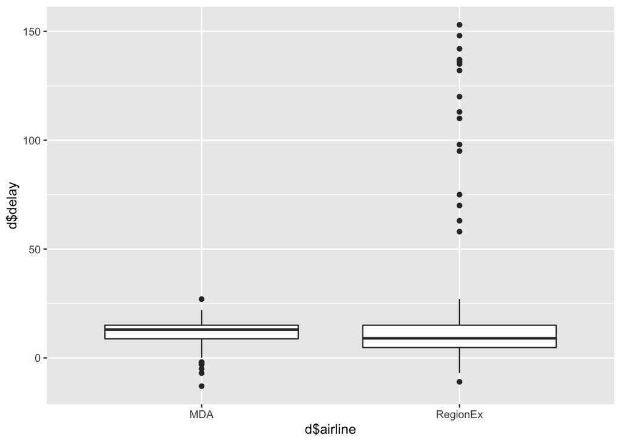

```r
ggplot(d, aes(x=d$airline,y = d$delay)) +
  geom_boxplot()
```

#### Response:

> By charting the data into a histogram we can observe the pressence of outliers inRegionEX is skewing the data to the right becasue of the outliers. and aditional plotting of the data using a BoxPlot shows a smaller ammount of observations for MDA in comparison to RegionEx, we can also see the central tendency measuer is lower than MDA.

### Q3

So far we have considered airline performance in terms of average delay in minutes. However, the performance metrics, as noted in the case description, also include the percentage of delayed flights. Let’s verify that MDA’s COO is correct: does RegionEx have a higher percentage of delayed flights?

Here is code to answer that question:

```r
# Create a summary table of percent delayed by airline.
d %>%
  group_by(airline) %>%
  summarize(n = n(),
            percent_delay = (mean(delay_indicator) * 100) %>% round(1))
```

```
## # A tibble: 2 x 3
##   airline      n percent_delay
##   <chr>    <int>         <dbl>
## 1 MDA        120          25.8
## 2 RegionEx   240          26.2
```

Note that because `delay_indicator` is numeric (a binary 0/1 variable) calculating the mean of the vector returns the proportion of 1s, which, multiplied by 100, is equivalent to the *percentage* of delayed flights.

Write your own code to create a table summarizing the percentage of delayed flights by airline *and route.*

```r
#Enrire dataset percentage (ontime/late)
table(d$delay_indicator) %>%
  prop.table
```

```
##
##         0         1
## 0.7388889 0.2611111
```

```r
# Sumary of percent delay by airline and route
d %>%
  group_by(airline, route_code) %>%
  summarize(
    n = n(),
    percent_delay = (mean(delay_indicator) * 100) %>% round(1)
  )
```

```
## # A tibble: 8 x 4
## # Groups:   airline [2]
##   airline  route_code     n percent_delay
##   <chr>    <chr>      <int>         <dbl>
## 1 MDA      DFW/MSY       30          26.7
## 2 MDA      MSY/DFW       30          30
## 3 MDA      MSY/PNS       30          20
## 4 MDA      PNS/MSY       30          26.7
## 5 RegionEx DFW/MSY       90          25.6
## 6 RegionEx MSY/DFW       90          28.9
## 7 RegionEx MSY/PNS       30          20
## 8 RegionEx PNS/MSY       30          26.7
```

These tables contain conflicting information. How should you answer the question of whether RegionEx has a higher percentage of delayed flights? Is the the COO correct? And, if not, why not?

#### Response:

> While reviewing the summary by Airline, the data shows that RegionEx has a 26.2 minutes percentage delay. By the other hand MDA has a 25.8 percentage delay. It would be very easy to presume that RegionEx has a greater percentage of delay. However once we breakit down even further by including the routes as well as the airline, we can see that RegionEx has a lower percent_delay when comparing aples to aples. In other words one fligh route agaisnt another flight rout from each airline. RegionEx has triple the flights observations point of data and when we compare same route for each airlines we see that routes of RegionEx of DFW/MSY and MSY/DFW have lower percentage delay per route than the routes of MDA of DFW/MSY and MSY/DFW.

### Q4

Compare the scheduled flight durations for the two airlines on each of their four routes. Compare the actual flight durations. What do you notice? If the two airlines had the same scheduled duration, what impact would this have on their delay records?

```r
# Sumary of percent delay by airline and route
d %>%
  group_by(airline, route_code) %>%
  summarize(
    n = n(),
    #percent_delay = (mean(delay_indicator) * 100) %>% round(1)
    schedule_time = (mean(scheduled_flight_length)) %>% round(1),
    actual_time = (mean(actual_flight_length)) %>% round(1),
    diference = actual_time - schedule_time


  )
```

```
## # A tibble: 8 x 6
## # Groups:   airline [2]
##   airline  route_code     n schedule_time actual_time diference
##   <chr>    <chr>      <int>         <dbl>       <dbl>     <dbl>
## 1 MDA      DFW/MSY       30           100       114.       13.5
## 2 MDA      MSY/DFW       30           100       114.       13.5
## 3 MDA      MSY/PNS       30            75        85.2      10.2
## 4 MDA      PNS/MSY       30            75        81.4       6.4
## 5 RegionEx DFW/MSY       90            90       106.       16.4
## 6 RegionEx MSY/DFW       90            90       108.       18.2
## 7 RegionEx MSY/PNS       30            70        81        11
## 8 RegionEx PNS/MSY       30            70        80.4      10.4
```

#### Response:

> We can observe from the information generated that RegionEx has a greater variation from scheduled to Actual time. Asuming that we replace RegionEx schedules to match those schedules of MDA and keep the actual filght time from RegionEx, the diference would be reduce mostly within the -+15 minute windows minute to be considered on time, with only very few exceptions. and dramatically decressed the airline delay.

### Q5

Does the data support the claim that the on‐time performance of RegionEx is worse than that of MDA? Write a paragraph in which you argue a position. In your answer, please incorporate the quantitative evidence you have developed above.

#### Response:

> RegionEx on time performance is really NOT worst than MDA, by the contrary in many instances they outperform MDA on time performance.  
> For a reason unknow from the data provided, RegionEx scheduled their flights 5-10 minutes shorter than MDA as seen in the “Sumary of percent delay by airline and route” table, where we can see the schedules of RegionEx routes DFW/MSY and MSY/DFW had a schedule flight of 90 minutes compared to MDA route DFW/MSY and MSY/DFW is 100 minutes for both routes.  
> We also see that RegionEx routes MSY/PNS and PNS/MSY have a schedule flight time of 70 minutes compared to MDA route MSY/PNS and PNS/MSY of 75 minutes.  
> This is why the numbers apeared to be higher for RegionEx in question 1 and in the report of the COO. it shows a mean of 10.9 minutes delay for MDA and a mean of 15.6 delay minutes for RegionEx. So, when we only observed the data grouped by airline only as in answered to question 1 “Compare the delay percent groupped by airline”, but once we break down the data to the same level of observations and use appropiate level of comparables, we can observed that RegionEx has more almost triple the number of flights (90 flights for RegionEx and 30 for MDA), and the bigger the sample the more accurate.  
> In Addition to that we see that routes of RegionEx for routes of DFW/MSY (25.6 minutes) and MSY/DFW (28.9 minutes) have lower percentage delay per route than the routes of MDA of DFW/MSY (26.7 minutes) and MSY/DFW (30.0 minutes) as explained in answer for question3.  
> Last but not least, as explained in the answered to question 4, the scheduled flights are lower in RegionEx than in MDA. That lowers the bar for RegionEx for when they get measured and therefore is more frequent for them to exceed the 15 minute window of on time performance. But to the eyes of the customers is simply not percived as worst delays than MDA, by the contrary actual flight times in minutes are lower on RegionEx.  
> What we can learn from this analysis that we need to carefull comparing data, to the lowest equivalent comparable. In this case compare “actual flight times” and “schedule flight time” from each airline and route to make a fair comparison.